# Metaweb of European vertebrates analysis

Marc Ohlmann

2022-07-26

## The European vertebrates data set

In this vignette, we aim at representing this large network using SBM groups.

## Loading the data set

```r
library(metanetwork)
library(igraph)
library(ggplot2)
library(ggimage)
```

```r
data("meta_vrtb")
print(meta_vrtb)
```

```
## metaweb has 1122 nodes and 49865 edges
## single network
## available resolutions are: sp group Class
```

```r
getwd()
```

```
## [1] "/home/me/Desktop/metanetwork_project/github/metanetwork/vignettes"
```

### Append aggregated networks

To compute aggregated networks at the SBM group level and Class level, we use the `append_agg_nets` method.

```r
meta_vrtb = append_agg_nets(meta_vrtb)
```

### Compute trophic levels

In order to represent this metaweb, we compute trophic levels since it is the first axis of ‘metanetwork’ layout.

```r
meta_vrtb = compute_TL(meta_vrtb)
```

We represent the distribution of trophic levels of the $4$ classes and $46$ SBM groups.

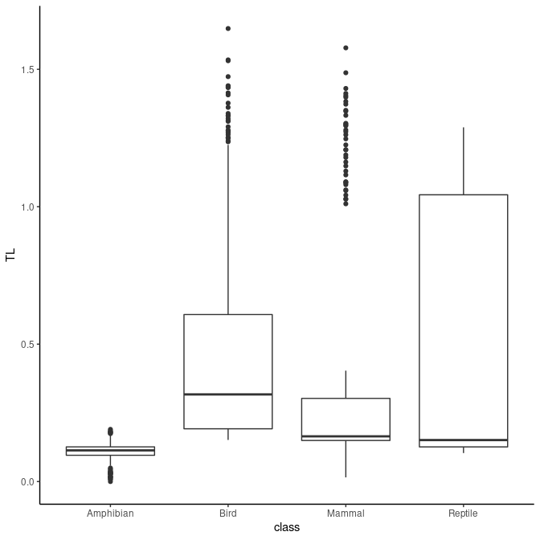

```r
TL_df = cbind(name = V(meta_vrtb$metaweb)$name,
              TL = V(meta_vrtb$metaweb)$TL,
              group = meta_vrtb$trophicTable[V(meta_vrtb$metaweb),"group"],
              class = meta_vrtb$trophicTable[V(meta_vrtb$metaweb),"Class"]) %>%
        as.data.frame()

TL_df$TL = as.numeric(TL_df$TL)

ggplot(TL_df, aes(x=class, y=TL)) +
  geom_boxplot() + theme_classic()
```

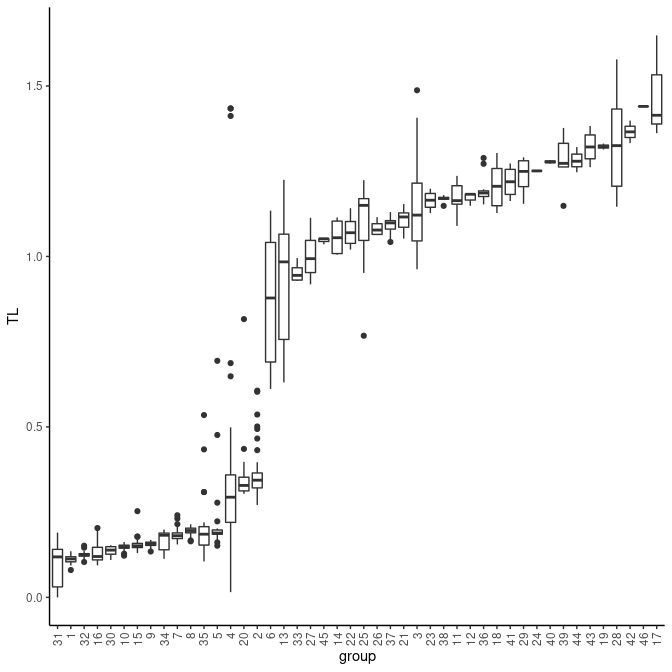

```r
ggplot(TL_df, aes(x=reorder(group, TL), y=TL)) +
  geom_boxplot() + theme_classic() + xlab("group") +
  theme(axis.text.x = element_text(angle = 90, vjust = 0.5, hjust=1))
```

We see that the four classes contain species of various trophic levels. SBM groups are more ordered in terms of trophic level, even if several trophic groups have similar trophic levels.

```r
#this group contains several eagles species
which(meta_vrtb$trophicTable[,"group"] == 17) %>% names()
```

```
## [1] "Accipiter_gentilis"   "Aquila_adalberti"     "Aquila_clanga"
## [4] "Aquila_heliaca"       "Hieraaetus_fasciatus" "Lynx_lynx"
## [7] "Hyaena_hyaena"
```

```r
#single group made of eagle-owl only
which(meta_vrtb$trophicTable[,"group"] == 46) %>% names()
```

```
## [1] "Bubo_bubo"
```

```r
#this one contain wolf and fox
which(meta_vrtb$trophicTable[,"group"] == 42) %>% names()
```

```
## [1] "Canis_lupus"   "Vulpes_vulpes"
```

## Represent the metaweb

In order to represent this large metaweb, we first represent the network at the SBM group level. We will use then the layout at the aggregated level to compute the layout at the species level. This layout is called `group-TL-tsne`, as `TL-tsne` is the diffusion based layout of `metanetwork`.

### Representation at the SBM level

Using `ggmetanet` and the precomputed layout for `beta = 0.005`, we first represent the web at the SBM group level

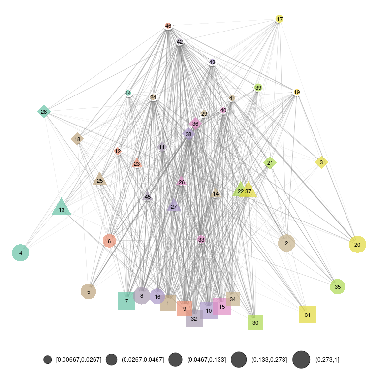

```r
beta = 0.005

#custom ggnet parameters
ggnet.custom = ggnet.default
ggnet.custom$label = T
ggnet.custom$edge.alpha = 0.5
ggnet.custom$alpha = 0.7
ggnet.custom$arrow.size = 1
ggnet.custom$max_size = 12

net_groups = ggmetanet(meta_vrtb,g = meta_vrtb$metaweb_group,flip_coords = T,
          beta = beta,legend = "group",
          ggnet.config = ggnet.custom,edge_thrs = 0.1)
net_groups
```

### group-TL-tsne layout

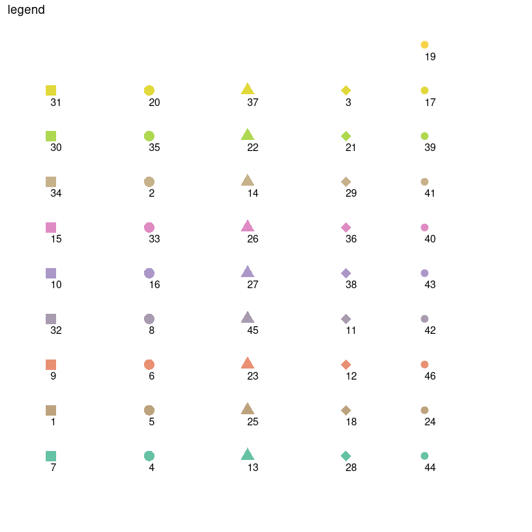

```r
beta = 0.005
ggnet.custom = ggnet.default
ggnet.custom$label = F
ggnet.custom$edge.alpha = 0.02
ggnet.custom$alpha = 0.7
ggnet.custom$arrow.size = 1
ggnet.custom$max_size = 4
ggnet.custom$palette = "Set2"
#add images in the legend
# ggnet.custom$img_PATH = "silouhette_metaweb_europe"

net_group_layout = ggmetanet(meta_vrtb,flip_coords = T,mode = "group-TL-tsne",
                             beta = beta,legend = "group",ggnet.config = ggnet.custom)
```

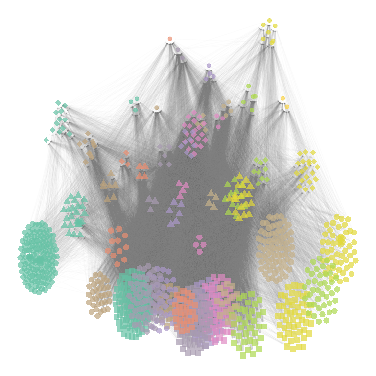

```r
net_group_layout
```

## References

Maiorano, L., Montemaggiori, A., Ficetola, G. F., O’connor, L., & Thuiller, W. (2020). TETRA‐EU 1.0: a species‐level trophic metaweb of European tetrapods. Global Ecology and Biogeography, 29(9), 1452-1457.

O’Connor, L. M., Pollock, L. J., Braga, J., Ficetola, G. F., Maiorano, L., Martinez‐Almoyna, C., … & Thuiller, W. (2020). Unveiling the food webs of tetrapods across Europe through the prism of the Eltonian niche. Journal of Biogeography, 47(1), 181-192.